# Practical Machine Learning Project

#### *Arthur: Di LU*

#### *Date: Feb. 18th, 2017*

#### *Revised: Feb. 20th, 2017*

#### Background

Using devices such as Jawbone Up, Nike FuelBand, and Fitbit it is now possible to collect a large amount of data about personal activity relatively inexpensively. These type of devices are part of the quantified self movement – a group of enthusiasts who take measurements about themselves regularly to improve their health, to find patterns in their behavior, or because they are tech geeks. One thing that people regularly do is quantify how much of a particular activity they do, but they rarely quantify how well they do it.

#### Data

The training data for this project are available here: https://d396qusza40orc.cloudfront.net/predmachlearn/pml-training.csv

The test data are available here: https://d396qusza40orc.cloudfront.net/predmachlearn/pml-testing.csv

#### Assignment requirements

In this project, your goal will be to use data from accelerometers on the belt, forearm, arm, and dumbell of 6 participants. They were asked to perform barbell lifts correctly and incorrectly in 5 different ways. More information is available from the website here: http://groupware.les.inf.puc-rio.br/har (see the section on the Weight Lifting Exercise Dataset).

#### Getting Data

```r
library(knitr)
library(caret)
```

```r
library(rpart)
library(rpart.plot)
library(RColorBrewer)
library(rattle)
library(randomForest)
trainUrl <- "http://d396qusza40orc.cloudfront.net/predmachlearn/pml-training.csv"
testUrl <- "http://d396qusza40orc.cloudfront.net/predmachlearn/pml-testing.csv"
training <- read.csv(url(trainUrl), na.strings=c("NA","#DIV/0!",""))
testing <- read.csv(url(testUrl), na.strings=c("NA","#DIV/0!",""))
```

#### Partitioning Data

```r
set.seed(20170218)
inTrain <- createDataPartition(y=training$classe, p=0.6, list=FALSE)
traindata <- training[inTrain, ];
validdata <- training[-inTrain, ]
dim(traindata); dim(validdata)
```

```
## [1] 11776   160
```

```
## [1] 7846  160
```

#### Cleaning Data

Remove NearZeroVariance variables

```r
nzv <- nearZeroVar(traindata, saveMetrics=TRUE)
traindata <- traindata[,nzv$nzv==FALSE]

nzv<- nearZeroVar(validdata,saveMetrics=TRUE)
validdata <- validdata[,nzv$nzv==FALSE]
```

Removing first ID variable

```r
traindata <- traindata[c(-1)]
```

Removing variables with too many NAs, set the threshold at 60%

```r
train_rmna <- traindata
for(i in 1:length(traindata)) {
  if( sum( is.na( traindata[, i] ) ) /nrow(traindata) >= .6) {
    for(j in 1:length(train_rmna)) {
      if( length( grep(names(traindata[i]), names(train_rmna)[j]) ) == 1)  {
        train_rmna <- train_rmna[ , -j]
      }
    }
  }
}

# Set back to the original variable name
traindata <- train_rmna
rm(train_rmna)
```

Applying the same procedures to validdata and testing datasets

```r
clean1 <- colnames(traindata)
clean2 <- colnames(traindata[, -58]) #already with classe column removed
validdata <- validdata[clean1]
testing <- testing[clean2]
```

Checking the new number of observations

```r
dim(validdata)
```

```
## [1] 7846   58
```

```r
dim(testing)
```

```
## [1] 20 57
```

Coercing the data into the same type

```r
for (i in 1:length(testing) ) {
  for(j in 1:length(traindata)) {
    if( length( grep(names(traindata[i]), names(testing)[j]) ) ==1)  {
      class(testing[j]) <- class(traindata[i])
    }
  }
}

testing <- rbind(traindata[2, -58] , testing)
testing <- testing[-1,]
```

#### *Cultivating Prediction Model 1:Decision Tree*

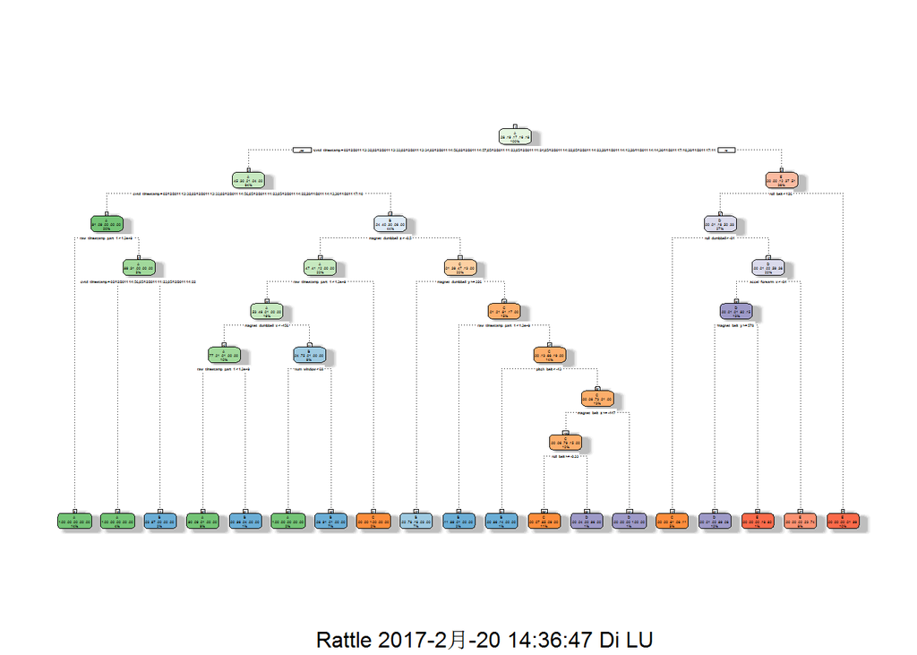

```r
predictionmodel1 <- rpart(classe ~ ., data=traindata, method="class")
fancyRpartPlot(predictionmodel1)
```

#### Predicting with decision tree model

```r
predictionresult1 <- predict(predictionmodel1, validdata, type = "class")
confusionMatrix(predictionresult1, validdata$classe)
```

```
## Confusion Matrix and Statistics
##
##           Reference
## Prediction    A    B    C    D    E
##          A 2149   62    9    2    0
##          B   80 1385  133   14    0
##          C    3   59 1181   96   62
##          D    0   12   32  935   80
##          E    0    0   13  239 1300
##
## Overall Statistics
##
##                Accuracy : 0.8858
##                  95% CI : (0.8786, 0.8928)
##     No Information Rate : 0.2845
##     P-Value [Acc > NIR] : < 2.2e-16
##
##                   Kappa : 0.8555
##  Mcnemar's Test P-Value : NA
##
## Statistics by Class:
##
##                      Class: A Class: B Class: C Class: D Class: E
## Sensitivity            0.9628   0.9124   0.8633   0.7271   0.9015
## Specificity            0.9870   0.9641   0.9660   0.9811   0.9606
## Pos Pred Value         0.9671   0.8592   0.8430   0.8829   0.8376
## Neg Pred Value         0.9852   0.9787   0.9710   0.9483   0.9774
## Prevalence             0.2845   0.1935   0.1744   0.1639   0.1838
## Detection Rate         0.2739   0.1765   0.1505   0.1192   0.1657
## Detection Prevalence   0.2832   0.2055   0.1786   0.1350   0.1978
## Balanced Accuracy      0.9749   0.9383   0.9147   0.8541   0.9311
```

#### Overall Statistics Report:

```r
##                Accuracy : 0.8858
##                  95% CI : (0.8786, 0.8928)
##     No Information Rate : 0.2845
##     P-Value [Acc > NIR] : < 2.2e-16
##
##                   Kappa : 0.8555
##  Mcnemar's Test P-Value : NA
```

##### With overall accuracy is 88.58%, out of sample error is 11.42%

#### *Cultivating Prediction Model 2:Random Forests*

```r
predictionmodel2 <- randomForest(classe ~. , data=traindata)
predictionresult2 <- predict(predictionmodel2, validdata, type = "class")
confusionMatrix(predictionresult2, validdata$classe)
```

```
## Confusion Matrix and Statistics
##
##           Reference
## Prediction    A    B    C    D    E
##          A 2232    1    0    0    0
##          B    0 1517    1    0    0
##          C    0    0 1364    2    0
##          D    0    0    3 1281    2
##          E    0    0    0    3 1440
##
## Overall Statistics
##
##                Accuracy : 0.9985
##                  95% CI : (0.9973, 0.9992)
##     No Information Rate : 0.2845
##     P-Value [Acc > NIR] : < 2.2e-16
##
##                   Kappa : 0.9981
##  Mcnemar's Test P-Value : NA
##
## Statistics by Class:
##
##                      Class: A Class: B Class: C Class: D Class: E
## Sensitivity            1.0000   0.9993   0.9971   0.9961   0.9986
## Specificity            0.9998   0.9998   0.9997   0.9992   0.9995
## Pos Pred Value         0.9996   0.9993   0.9985   0.9961   0.9979
## Neg Pred Value         1.0000   0.9998   0.9994   0.9992   0.9997
## Prevalence             0.2845   0.1935   0.1744   0.1639   0.1838
## Detection Rate         0.2845   0.1933   0.1738   0.1633   0.1835
## Detection Prevalence   0.2846   0.1935   0.1741   0.1639   0.1839
## Balanced Accuracy      0.9999   0.9996   0.9984   0.9977   0.9991
```

Overall Statistics report:

```r
##                Accuracy : 0.9985
##                  95% CI : (0.9973, 0.9992)
##     No Information Rate : 0.2845
##     P-Value [Acc > NIR] : < 2.2e-16
##
##                   Kappa : 0.9981
##  Mcnemar's Test P-Value : NA
```

##### With overall accuracy is 99.85%, out of sample error is 0.15%

#### With comparisons of OOS-error between the two models, we can tell that random forests predicts with higher accuracy with 99.85%, and OOS-error with 0.15%. So we will adopt this model in prediction of testing data.

#### *Apply the prediction model to the testing data*:

```r
predictions2 <- predict(predictionmodel2, testing, type = "class")
predictions2
```

```
##  1  2  3 41  5  6  7  8  9 10 11 12 13 14 15 16 17 18 19 20
##  B  A  B  A  A  E  D  B  A  A  B  C  B  A  E  E  A  B  B  B
## Levels: A B C D E
```

#### Generate the files for submission with the given R code from the assignment.

```r
pml_write_files = function(x){
  n = length(x)
  for(i in 1:n){
    filename = paste0("problem_id_",i,".txt")
    write.table(x[i],file=filename,quote=FALSE,row.names=FALSE,col.names=FALSE)
  }
}

pml_write_files(predictions2)
```